# PART 2

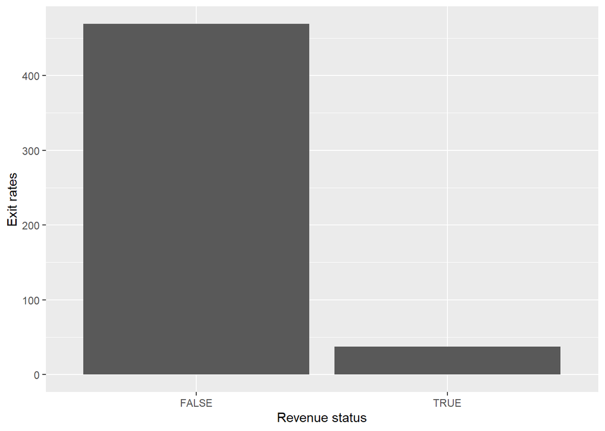

```r
ggplot(df2, aes(Revenue, ExitRates)) +
    geom_bar(stat = "identity") +
    labs(y = "Exit rates", x = "Revenue status")
```

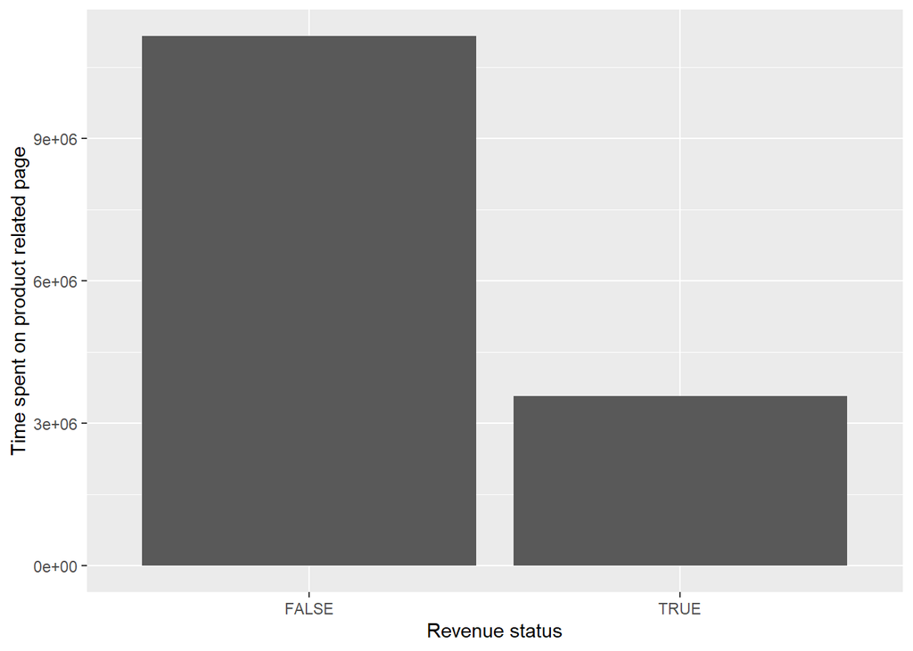

```r
ggplot(df2, aes(Revenue, ProductRelated_Duration)) +
    geom_bar(stat = "identity") +
    labs(y = "Time spent on product related page", x = "Revenue status")
```

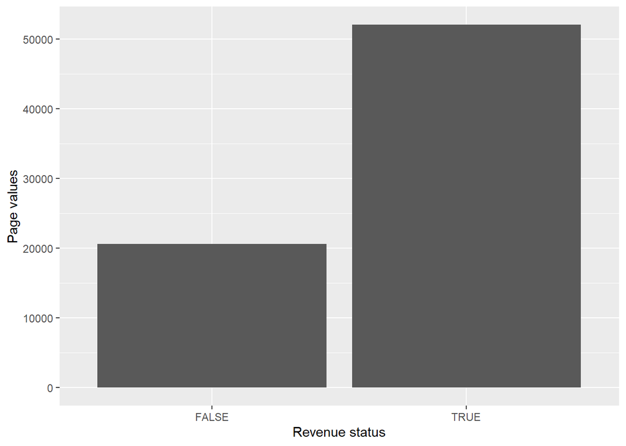

```r
ggplot(df2, aes(Revenue, PageValues)) +
    geom_bar(stat = "identity") +
    labs(y = "Page values", x = "Revenue status")
```

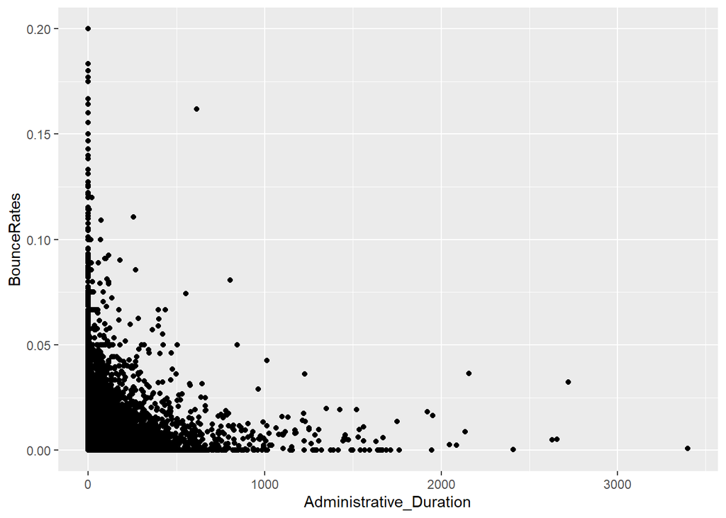

```r
# between continuous variables

ggplot(df2,
       aes(x = Administrative_Duration,
           y = BounceRates)) +
  geom_point()
```

```r
cor(df2$Administrative_Duration,df2$BounceRates)
```

```
## [1] -0.1373334
```

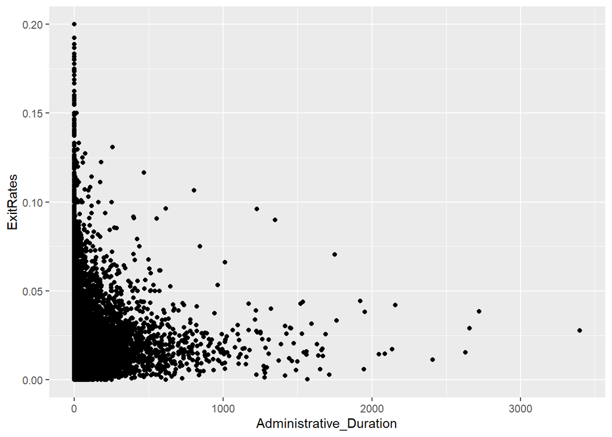

```r
ggplot(df2,
       aes(x = Administrative_Duration,
           y = ExitRates)) +
  geom_point()
```

```r
cor(df2$Administrative_Duration,df2$ExitRates)
```

```
## [1] -0.2020245
```

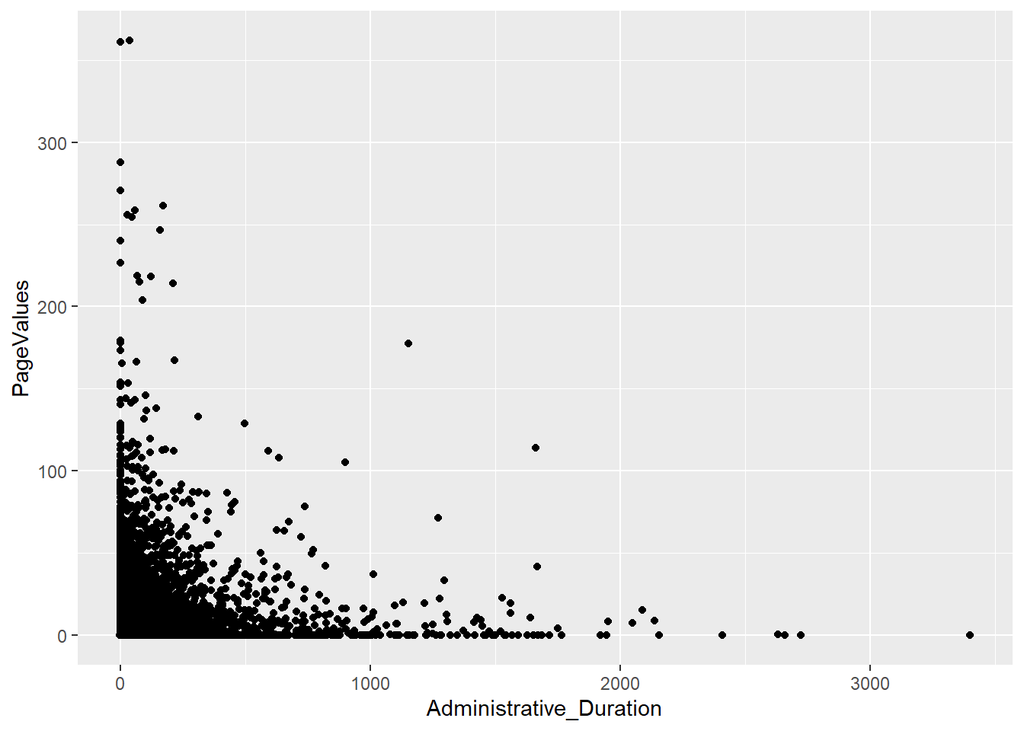

```r
ggplot(df2,
       aes(x = Administrative_Duration,
           y = PageValues)) +
  geom_point()
```

```r
cor(df2$Administrative_Duration,df2$PageValues)
```

```
## [1] 0.06616837
```

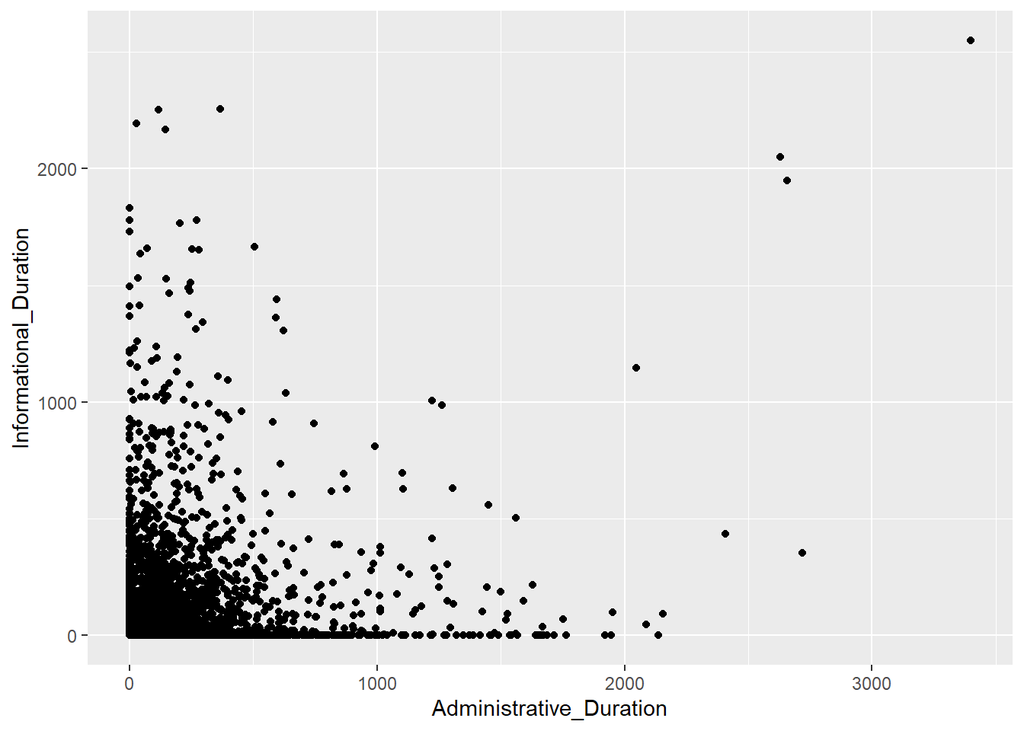

```r
ggplot(df2,
       aes(x = Administrative_Duration,
           y = Informational_Duration)) +
  geom_point()
```

```r
cor(df2$Administrative_Duration,df2$Informational_Duration)
```

```
## [1] 0.2371899
```

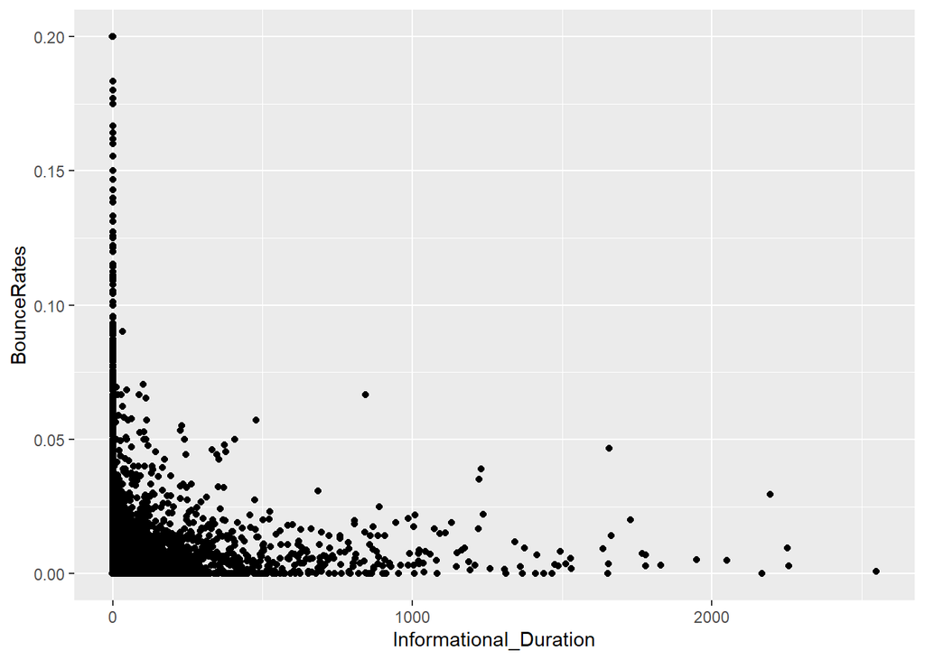

```r
ggplot(df2,
       aes(x = Informational_Duration,
           y = BounceRates)) +
  geom_point()
```

```r
cor(df2$Informational_Duration,df2$BounceRates)
```

```
## [1] -0.07015947
```

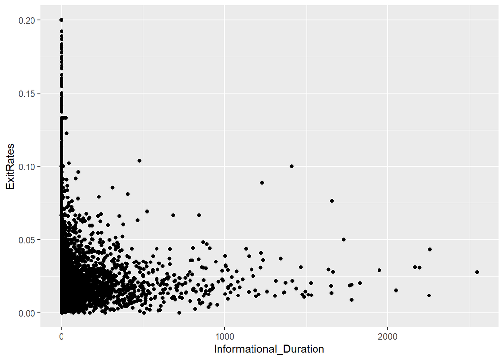

```r
ggplot(df2,
       aes(x = Informational_Duration,
           y = ExitRates)) +
  geom_point()
```

```r
cor(df2$Informational_Duration,df2$ExitRates)
```

```
## [1] -0.1029327
```

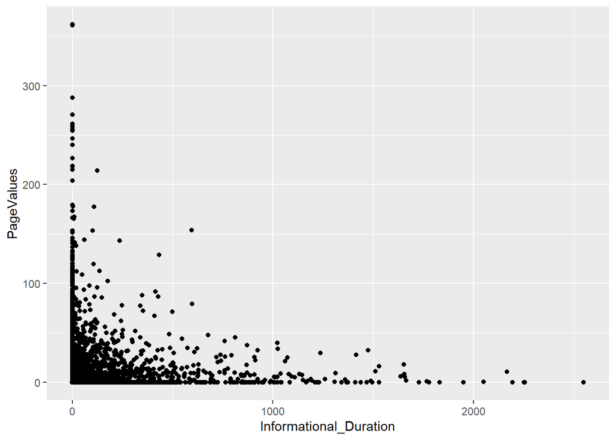

```r
ggplot(df2,
       aes(x = Informational_Duration,
           y = PageValues)) +
  geom_point()
```

```r
cor(df2$Informational_Duration,df2$PageValues)
```

```
## [1] 0.03006416
```

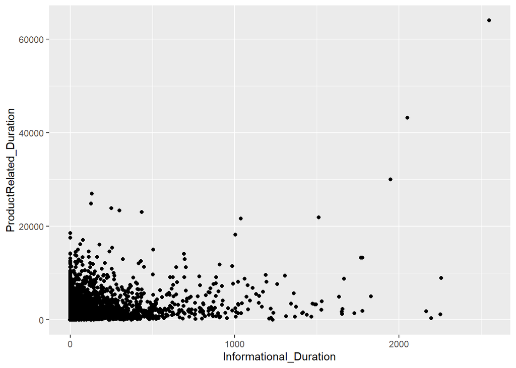

```r
ggplot(df2,
       aes(x = Informational_Duration,
           y = ProductRelated_Duration)) +
  geom_point()
```

```r
cor(df2$Informational_Duration,df2$ProductRelated_Duration)
```

```
## [1] 0.3465807
```

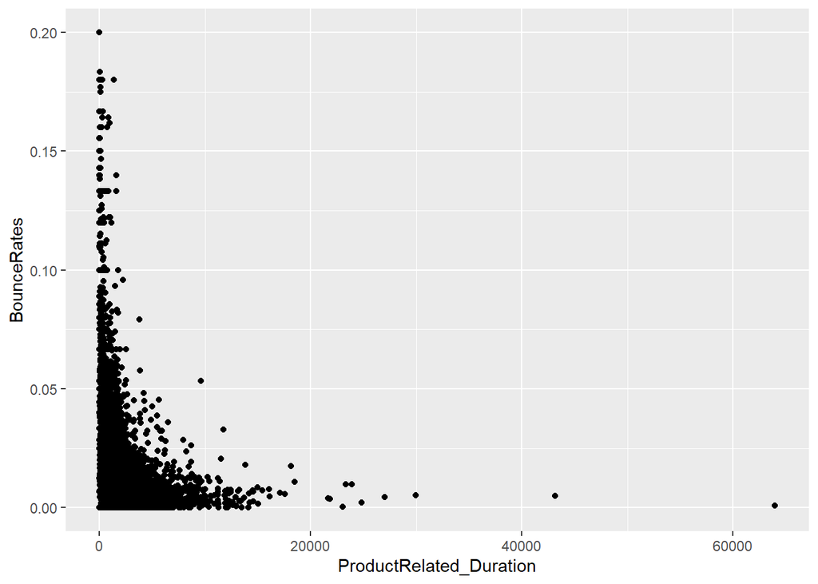

```r
ggplot(df2,
       aes(x = ProductRelated_Duration,
           y = BounceRates)) +
  geom_point()
```

```r
cor(df2$ProductRelated_Duration,df2$BounceRates)
```

```
## [1] -0.1743755
```

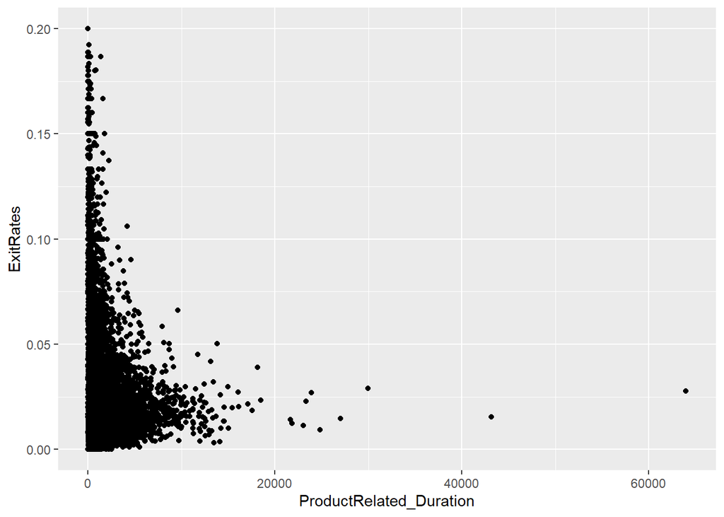

```r
ggplot(df2,
       aes(x = ProductRelated_Duration,
           y = ExitRates)) +
  geom_point()
```

```r
cor(df2$ProductRelated_Duration,df2$ExitRates)
```

```
## [1] -0.245334
```

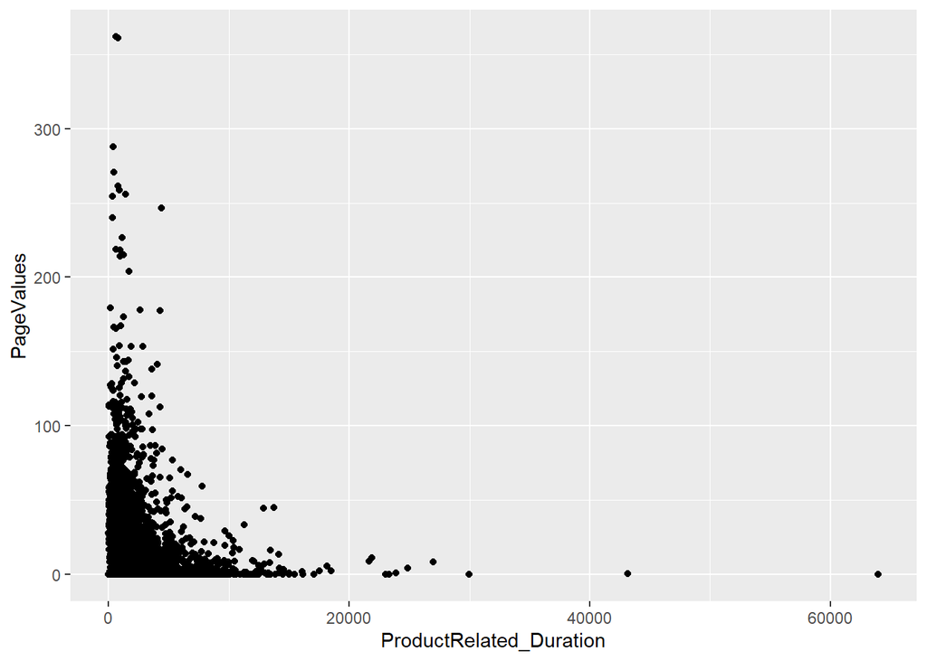

```r
ggplot(df2,
       aes(x = ProductRelated_Duration,
           y = PageValues)) +
  geom_point()
```

```r
cor(df2$ProductRelated_Duration,df2$PageValues)
```

```
## [1] 0.05084062
```

- More people bring in revenue on weekdays compared to weekends.
- New visitors who do not bring in revenue are higher than the new ones who do. Same goes for returning visitors. However a higher number of returning visitors bring in revenue compared to new visitors.
- Returning visitors are more than new visitors both on weekdays and weekends.
- November has the highest revenue while February has the lowest.
- May has the highest number of returning visitors while Feb has the lowest. November has the highest number of new visitors while Feb has the lowest.
- Number of visits on administrative, Informational page translating into revenue are lower than those that don’t bring in revenue.
- A higher percentage that was the last in the session translates into no revenue compared to a lower percentage that generates revenue.
- More time spent on product related page doesn’t necessarily translate into revenue.
- Exit rates and bounce rates are low for visitors that generate revenue while they are higher for visitors that don’t generate revenue.
- Page value is higher in visitors that produce revenue compared to those who don’t.
- Exit rates and bounce rates are positively correlated, meaning an increase in one leads to increase in another.
- Exit rates is negatively correlated with duration spent on product page, hence an increase in duration leads to decrease in exit rate and vice versa.

## 6.)Implement the Solution

### 6.1) K-Means Clustering

```r
a <- names(df2)[sapply(df2, is.integer)]
a
```

```
## [1] "Administrative"   "Informational"    "ProductRelated"   "OperatingSystems"
## [5] "Browser"          "Region"           "TrafficType"
```

```r
df3 <- df2[,-c("Revenue", "Administrative", "Informational", "ProductRelated", "OperatingSystems"
, "Browser", "Region", "TrafficType","Month","Weekend","VisitorType")] # exctracting numerical data only
df3.class<- df2[, c("Revenue","Month","Weekend","VisitorType")]
head(df3)
```

```
##    Administrative_Duration Informational_Duration ProductRelated_Duration
## 1:                       0                      0                0.000000
## 2:                       0                      0               64.000000
## 3:                      -1                     -1               -1.000000
## 4:                       0                      0                2.666667
## 5:                       0                      0              627.500000
## 6:                       0                      0              154.216667
##    BounceRates ExitRates PageValues SpecialDay
## 1:  0.20000000 0.2000000          0          0
## 2:  0.00000000 0.1000000          0          0
## 3:  0.20000000 0.2000000          0          0
## 4:  0.05000000 0.1400000          0          0
## 5:  0.02000000 0.0500000          0          0
## 6:  0.01578947 0.0245614          0          0
```

```r
head (df3.class)
```

```
##    Revenue Month Weekend       VisitorType
## 1:   FALSE   Feb   FALSE Returning_Visitor
## 2:   FALSE   Feb   FALSE Returning_Visitor
## 3:   FALSE   Feb   FALSE Returning_Visitor
## 4:   FALSE   Feb   FALSE Returning_Visitor
## 5:   FALSE   Feb    TRUE Returning_Visitor
## 6:   FALSE   Feb   FALSE Returning_Visitor
```

```r
str(df3)
```

```
## Classes 'data.table' and 'data.frame':   12199 obs. of  7 variables:
##  $ Administrative_Duration: num  0 0 -1 0 0 0 -1 -1 0 0 ...
##  $ Informational_Duration : num  0 0 -1 0 0 0 -1 -1 0 0 ...
##  $ ProductRelated_Duration: num  0 64 -1 2.67 627.5 ...
##  $ BounceRates            : num  0.2 0 0.2 0.05 0.02 ...
##  $ ExitRates              : num  0.2 0.1 0.2 0.14 0.05 ...
##  $ PageValues             : num  0 0 0 0 0 0 0 0 0 0 ...
##  $ SpecialDay             : num  0 0 0 0 0 0 0.4 0 0.8 0.4 ...
##  - attr(*, ".internal.selfref")=<externalptr>
```

```r
# Normalization
normalize <- function(x){
  return ((x-min(x)) / (max(x)-min(x)))
}

df3 <- normalize(df3)
head(df3)
```

```
##    Administrative_Duration Informational_Duration ProductRelated_Duration
## 1:            1.563122e-05           1.563122e-05            1.563122e-05
## 2:            1.563122e-05           1.563122e-05            1.016029e-03
## 3:            0.000000e+00           0.000000e+00            0.000000e+00
## 4:            1.563122e-05           1.563122e-05            5.731448e-05
## 5:            1.563122e-05           1.563122e-05            9.824223e-03
## 6:            1.563122e-05           1.563122e-05            2.426226e-03
##     BounceRates    ExitRates   PageValues   SpecialDay
## 1: 1.875747e-05 1.875747e-05 1.563122e-05 1.563122e-05
## 2: 1.563122e-05 1.719434e-05 1.563122e-05 1.563122e-05
## 3: 1.875747e-05 1.875747e-05 1.563122e-05 1.563122e-05
## 4: 1.641278e-05 1.781959e-05 1.563122e-05 1.563122e-05
## 5: 1.594385e-05 1.641278e-05 1.563122e-05 1.563122e-05
## 6: 1.587803e-05 1.601515e-05 1.563122e-05 1.563122e-05
```

```r
# Applying the K-means clustering algorithm with (k)=2

kmeans <- kmeans(df3,2)
kmeans
```

```
## K-means clustering with 2 clusters of sizes 11268, 931
##
## Cluster means:
##   Administrative_Duration Informational_Duration ProductRelated_Duration
## 1             0.001129456           0.0004160594              0.01257321
## 2             0.003264835           0.0023045064              0.09534883
##    BounceRates    ExitRates   PageValues   SpecialDay
## 1 1.596882e-05 1.630663e-05 0.0001068563 1.662059e-05
## 2 1.573311e-05 1.595592e-05 0.0001307008 1.634982e-05
##
## Clustering vector:
##     [1] 1 1 1 1 1 1 1 1 1 1 1 1 1 1 1 1 1 1 1 1 1 1 1 1 1 1 1 1 1 1 1 1 1 1 1 1
##    [37] 1 1 1 1 2 1 1 1 1 1 1 1 1 1 1 1 1 1 1 1 1 1 1 1 1 1 1 1 1 1 2 1 1 1 1 1
##    [73] 1 1 1 1 1 1 1 1 1 1 1 1 1 1 1 1 1 1 1 1 1 1 1 1 1 1 1 1 1 1 1 1 1 1 1 1
##   [109] 1 2 1 1 1 1 1 1 1 1 1 1 1 1 1 1 1 1 1 1 1 1 1 1 1 1 1 1 1 1 1 1 1 1 1 1
```

[output cut: 344 more lines]

```r
kmeans$centers # Getting the value of cluster center data point value(2 centers for k=2)
```

```
##   Administrative_Duration Informational_Duration ProductRelated_Duration
## 1             0.001129456           0.0004160594              0.01257321
## 2             0.003264835           0.0023045064              0.09534883
##    BounceRates    ExitRates   PageValues   SpecialDay
## 1 1.596882e-05 1.630663e-05 0.0001068563 1.662059e-05
## 2 1.573311e-05 1.595592e-05 0.0001307008 1.634982e-05
```

```r
kmeans$cluster # showing distribution of members per cluster
```

```
##     [1] 1 1 1 1 1 1 1 1 1 1 1 1 1 1 1 1 1 1 1 1 1 1 1 1 1 1 1 1 1 1 1 1 1 1 1 1
##    [37] 1 1 1 1 2 1 1 1 1 1 1 1 1 1 1 1 1 1 1 1 1 1 1 1 1 1 1 1 1 1 2 1 1 1 1 1
##    [73] 1 1 1 1 1 1 1 1 1 1 1 1 1 1 1 1 1 1 1 1 1 1 1 1 1 1 1 1 1 1 1 1 1 1 1 1
##   [109] 1 2 1 1 1 1 1 1 1 1 1 1 1 1 1 1 1 1 1 1 1 1 1 1 1 1 1 1 1 1 1 1 1 1 1 1
##   [145] 1 1 1 1 1 1 1 1 1 1 1 1 1 1 1 1 1 1 1 1 1 1 1 1 1 1 1 1 1 1 1 1 1 1 1 1
##   [181] 1 1 1 1 1 1 1 1 1 1 1 1 1 2 1 1 1 1 1 1 1 1 1 1 1 1 1 1 1 1 1 1 1 1 1 1
##   [217] 1 1 1 1 1 1 1 1 1 1 1 1 1 1 1 1 1 1 1 1 1 1 1 1 1 1 1 1 1 1 1 1 1 2 1 1
##   [253] 1 1 1 1 1 1 1 1 1 1 1 2 1 1 1 1 1 1 1 1 1 1 1 2 1 1 1 1 1 1 1 1 1 1 1 1
##   [289] 1 1 1 1 1 1 1 1 1 1 1 1 1 1 1 1 1 1 1 1 1 1 1 1 1 1 1 1 1 1 1 1 1 1 1 1
##   [325] 1 1 1 1 1 1 1 1 2 1 1 1 1 1 1 1 1 1 1 1 1 1 1 1 1 1 1 1 1 1 1 1 1 1 1 1
##   [361] 1 1 1 1 1 2 1 1 1 1 1 1 1 1 1 1 1 1 1 1 1 1 1 1 1 1 1 1 1 1 1 1 1 1 1 1
##   [397] 1 1 1 1 1 1 1 1 1 1 1 1 1 1 1 1 1 1 1 1 1 1 1 1 1 2 1 1 1 1 1 1 1 1 1 1
##   [433] 1 1 1 1 1 1 1 1 1 1 1 1 1 1 1 1 1 1 1 1 1 1 1 1 1 1 1 1 1 1 1 1 1 1 2 1
##   [469] 1 1 1 1 1 2 1 1 1 1 1 1 1 1 1 1 1 1 1 1 1 1 1 1 1 1 1 1 1 1 1 1 1 1 1 1
##   [505] 1 2 1 1 1 1 1 1 1 1 1 1 1 1 1 1 1 1 1 1 1 1 1 1 1 1 1 1 1 1 1 1 1 1 1 1
```

[output cut: 324 more lines]

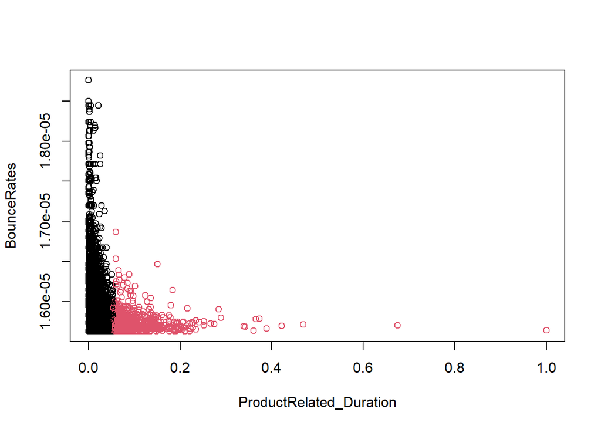

```r
plot(df3[,3:4], col = kmeans$cluster) # shows how data in features bounce rates and product related duration is split into 2 clusters
```

-2 clusters of sizes 11268, 931. - sample 2 has the lowest distance(1.887334) between it’s components while sample 1 has the highest distance(3.354206) between components.

We perform this exercise in a loop to find updated cluster centers and allocation of each observation. The iteration will stop when the maximum number of iterations is reached or the change of within-cluster sum of squares in two successive iterations is less than the threshold value. The updated cluster centers for the last iteration are called Final Cluster Centers.

- 53% is a measure of the total variance in the data set that is explained by the clustering. k-means minimizes the within group dispersion and maximizes the between-group dispersion. By assigning the samples to k clusters rather than n (number of samples) clusters achieved a reduction in sums of squares of 53%.

_ K-Means Clustering was advantageous to use as it was easy to implement.However, it is sensitive to scale and since we normalized the dataset,it completely changed results.

# 6.2) Hierarchical Clustering

```r
head(df3)
```

```
##    Administrative_Duration Informational_Duration ProductRelated_Duration
## 1:            1.563122e-05           1.563122e-05            1.563122e-05
## 2:            1.563122e-05           1.563122e-05            1.016029e-03
## 3:            0.000000e+00           0.000000e+00            0.000000e+00
## 4:            1.563122e-05           1.563122e-05            5.731448e-05
## 5:            1.563122e-05           1.563122e-05            9.824223e-03
## 6:            1.563122e-05           1.563122e-05            2.426226e-03
##     BounceRates    ExitRates   PageValues   SpecialDay
## 1: 1.875747e-05 1.875747e-05 1.563122e-05 1.563122e-05
## 2: 1.563122e-05 1.719434e-05 1.563122e-05 1.563122e-05
## 3: 1.875747e-05 1.875747e-05 1.563122e-05 1.563122e-05
## 4: 1.641278e-05 1.781959e-05 1.563122e-05 1.563122e-05
## 5: 1.594385e-05 1.641278e-05 1.563122e-05 1.563122e-05
## 6: 1.587803e-05 1.601515e-05 1.563122e-05 1.563122e-05
```

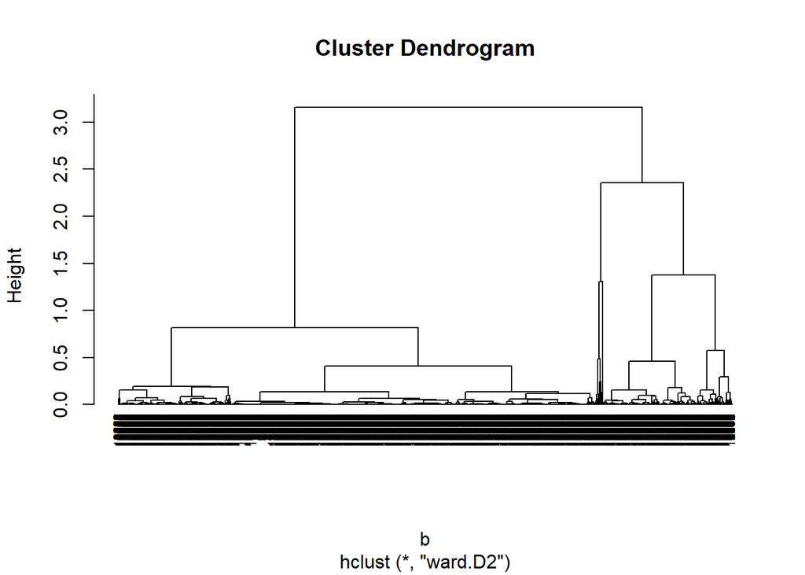

```r
# Computing the Euclidean distance between observations using dist()

b <- dist(df3, method = "euclidean")
#print(b,digits=3)

# Hierarchical clustering. By default, it uses complete linkage
complete.hc <- hclust(b,method = "ward.D2")

# Plotting the dendrogram

plot(complete.hc,cex = 0.6, hang = -1)
```

```r
# checking cluster membership
complete.member <- cutree(complete.hc,2)
table(complete.member)
```

```
## complete.member
##    1    2
## 9489 2710
```

- No need to specify the number of clusters is an advantage of this cluster type. It is also easy to implement.
- When clustered into 2, 9489 components cluster in 1 while 2710 are in 2.

## 7.)Challenge the Solution

- Hierarchical clusters better in this case compared to kmeans when k=2

## 8.)Follow up Questions

- What is needed to be done in order for classifications to be more precise.